# How to build a Cartesian space

## Introduction

Euclidian space is a fundamental concept in mathematics. It is defined by a set of axioms.

- [Euclidean geometry](https://en.wikipedia.org/wiki/Euclidean_geometry)
- [Hilbert’s axioms](https://en.wikipedia.org/wiki/Hilbert%27s_axioms)

In euclidean space, we have few basic concepts:

**Primitive terms**

- Points
- Lines
- Planes

**Primitive relations**

- Betweenness
- Lies on
- Congruence

Using just axioms of Euclidean geometry it is very hard proving new theorems. Thanks to [Decartes](https://en.wikipedia.org/wiki/Ren%C3%A9_Descartes) we can introduce a new concept called Cartesian space. This new approach allows us to use numbers and algebra to describe the objects and relations in the Euclidean space.

Now we will build a [Cartesian space](https://en.wikipedia.org/wiki/Analytic_geometry) step by step.

## Building a Cartesian space

#### **Take a Euclidean plane**

This is pure Euclidean plane.

#### **Draw a line**

You can draw any line you want. We will call it $x$.

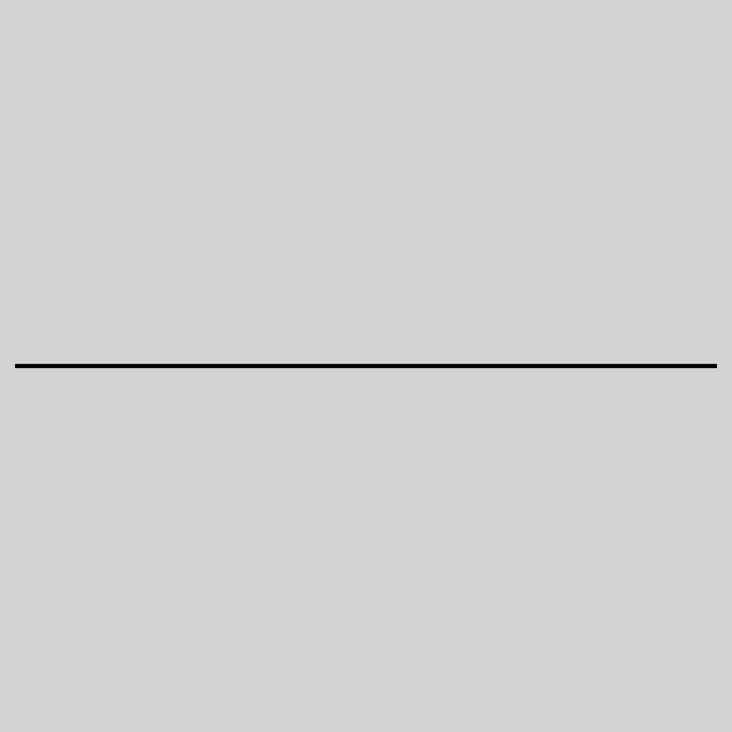

#### **Choose a point on the line**

You can choose any point on the line.

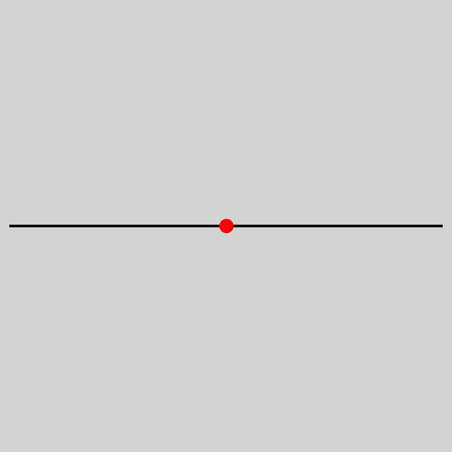

#### **Draw a perpendicular line**

By axioms of Euclidean geometry, you can draw a perpendicular line to the first line which passes through the chosen point. This line is unique and it passes through the chosen point. We will call this line $y$.

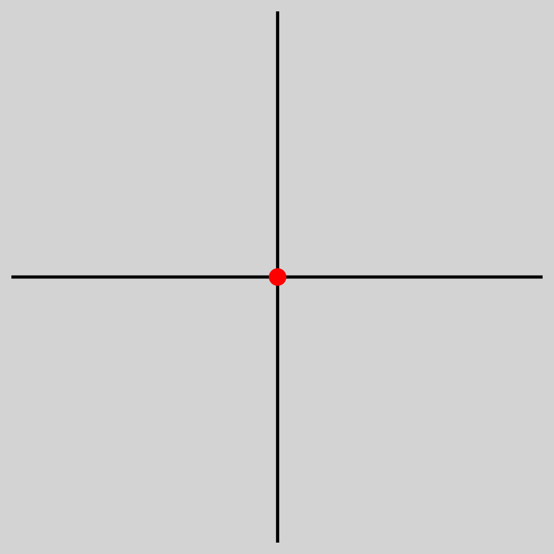

A red point is called the origin of the Cartesian space. Lines are called the axes of the Cartesian space.

#### **Defining the unit length**

Now, you can choose second point on $x$-axis different from the origin. Distance between two points will be called an unit length of the Cartesian space.

By eculidean axioms, you can fill the whole $x$-axis with points which are separated by the unit length.

Also by axioms of Euclidean geometry, you can find a point on the $y$-axis such that distance between this point and the origin is equal to the unit length and further points on the $y$-axis are separated by the unit length.

By doing this, we introduce numbers to the Euclidian space.

Those numbers describe the position of the points on the each axis.

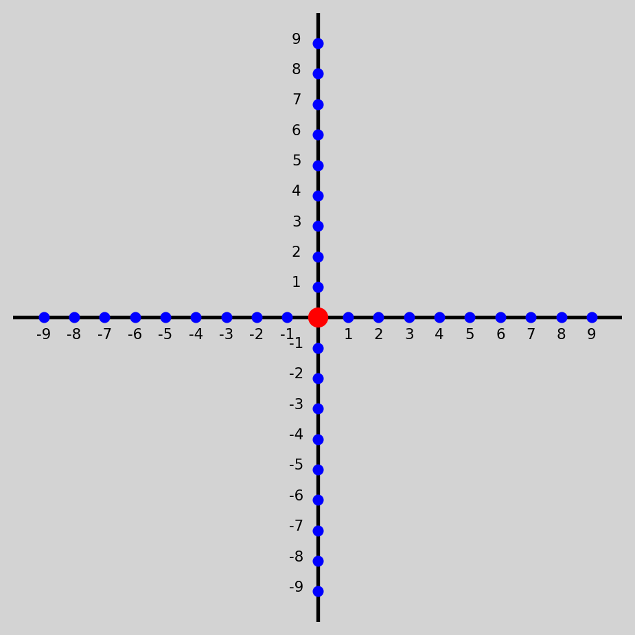

#### **Describing the position of any point**

Let’s consider any point $P$ on the plane. From the axioms of Euclidean geometry, we know that there exists a unique line passing through this point that is perpendicular to the first axis. Similarly, there is a unique line that is perpendicular to the second axis and passes through point $P$. These lines intersect the axes at unique points $A$ and $B$, respectively. Since, for any point $P$, there are unique points $A$ and $B$ on the axes, we can define the position of $P$ by these numbers. We call these numbers the coordinates of point $P$.

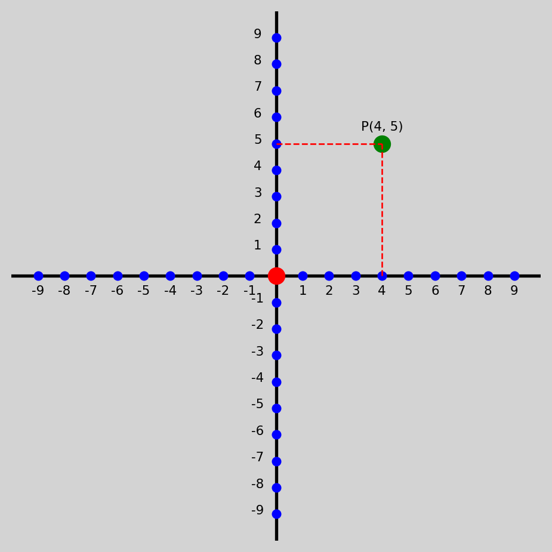

#### **Summary**

We have built a Cartesian space. We have introduced numbers to the Euclidean space. We can describe the position of any point by two numbers. We can use algebra to describe the relations between points in the Euclidean space.

## Cartesian space

Below we present some basic terms and operations in the Cartesian space.

#### Distance between two points

The distance between two points $P_1=(x_1, y_1)$ and $P_2=(x_2, y_2)$ is given by the formula:

$$d(P_1, P_2) = \sqrt{(x_2 - x_1)^2 + (y_2 - y_1)^2}$$

#### Midpoint of a line segment

The midpoint of a line segment with endpoints $P_1=(x_1, y_1)$ and $P_2=(x_2, y_2)$ is given by the formula:

$$M(P_1, P_2)=\left(\frac{x_1 + x_2}{2}, \frac{y_1 + y_2}{2}\right)$$

#### Addition of two points

The sum of two points $P_1(x_1, y_1)$ and $P_2(x_2, y_2)$ is given by the formula:

$$P_1 + P_2 = (x_1 + x_2, y_1 + y_2)$$

#### Subtraction of two points

The difference of two points $P_1(x_1, y_1)$ and $P_2(x_2, y_2)$ is given by the formula:

$$P_1 - P_2 = (x_1 - x_2, y_1 - y_2)$$

#### Multiplication of a point by a scalar

The multiplication of a point $P(x, y)$ by a scalar $k$ is given by the formula:

$$k \cdot P = (k \cdot x, k \cdot y)$$

#### Vector

Ordered two points $P_1(x_1, y_1)$ and $P_2(x_2, y_2)$ define a vector. On plane vector is represented by an arrow pointing from $P_1$ to $P_2$.

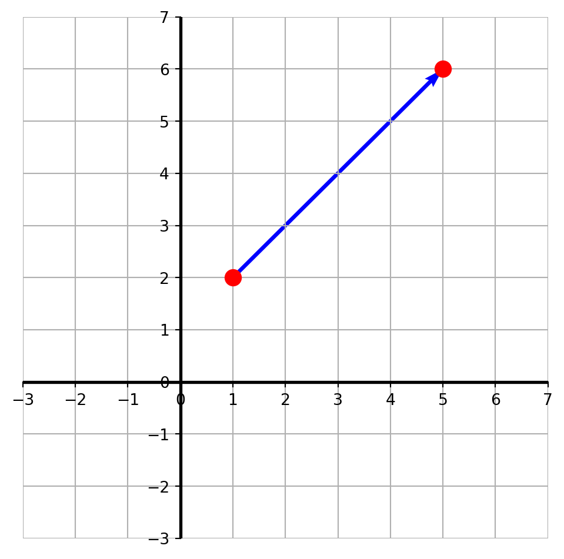